# (Prosper Loan Dataset Visual Analysis)

## by (Ujwala K)

## Investigation Overview

> Mainly my focus will be to answer below questions:-¶

> 1)Factors responsible for loan status outcome such as completed or cancelled or past-due etc

> 2)Factors affecting borrower's APR(which usually includes broker fees, closing costs, rebates, and discount points) and borrower's interest rate

> 3)Large loan amount differentiation factors(Are there differences between loans depending on how large the original loan amount was?)

## Dataset Overview

> This data set contains 113,937 loans with 81 variables on each loan, including loan amount, borrower rate (or interest rate), current loan status, borrower income, and many others.

## Borrower APR vs. Loan Amount

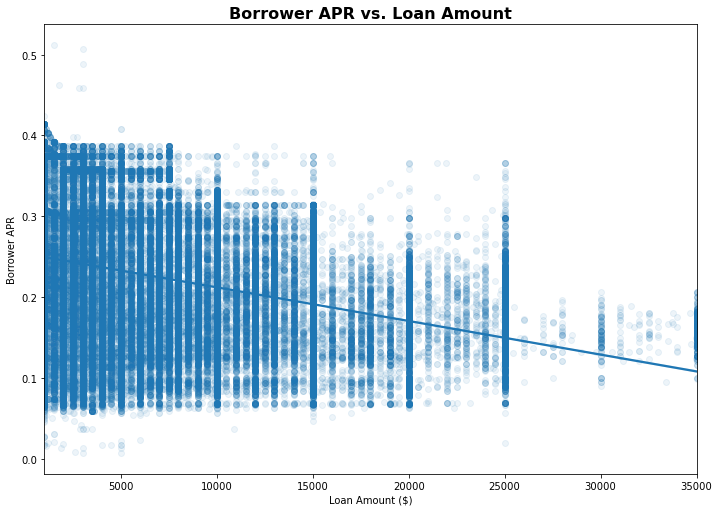

## BorrowerAPR and LoanOriginalAmount relation with categorical Term and Credit-ProsperScores

> 2)Borrowers with better rating also have higher loan amount.

> 3)For higher Loan Amounts , term is also high.

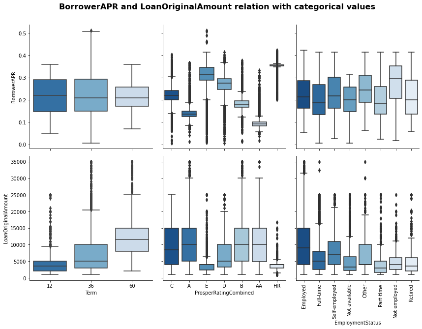

## Heatmap of Median Estimated Returns by Credit Rating and Income Range

From the heat map we can see that for lower credit ratings, and lower incomes we have higher estimated returns. However income range is not influencing the estimated returns by credit rating category.

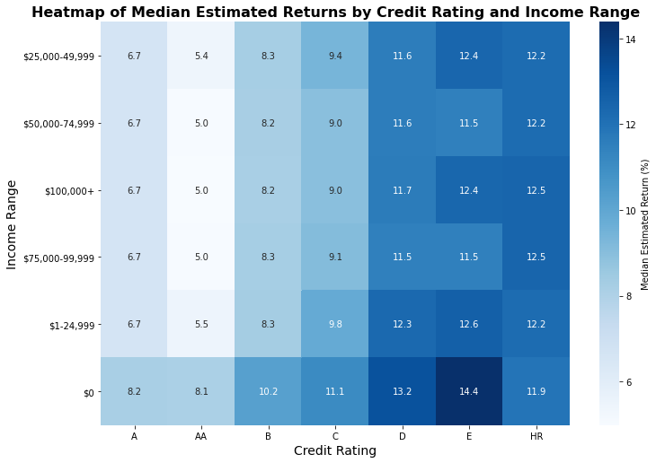

## Pairplot for BorrowerAPR and Estimated loss , Return relationship

Its clear from the plots that BorrowerAPR has positive relationship with EstimatedLoss and EstimatedReturn , BorrowerAPR increases with both of them.

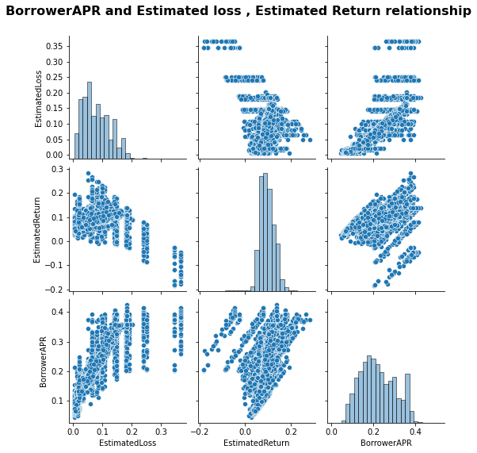

## LoanStatus and Estimated loss , Return relationship

From the Box plots ,we can observe that ChargedOff and Defaulted Loan Statuses Borrowers have higher EstimatedLoss and EstimatedReturn percentage

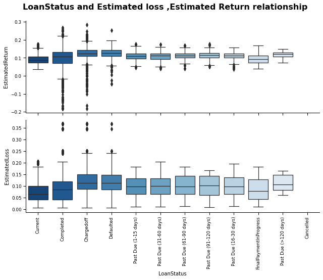

## Conclusion for Visual Explanatory Analysis Observations from different plots

3)Borrowers with better rating also have higher loan amount.

4)For higher Loan Amounts , term is also high.

5)From the heat map we can see that for lower credit ratings, and lower incomes we have higher estimated returns. However income range is not influencing the estimated returns by credit rating category.

6)Its clear from the plots that BorrowerAPR has positive relationship with EstimatedLoss and EstimatedReturn , BorrowerAPR increases with both of them.

7)From the Box plots ,we can observe that ChargedOff and Defaulted Loan Statuses Borrowers have higher EstimatedLoss and EstimatedReturn percentage